# EDA and Visualization Assignment

Question 1

1 & 2

```python
import pandas as pd
import numpy as np
```

```python
import matplotlib.pyplot as plt
```

```python
file_path = '~/Downloads/college_completion.csv'
```

```python
df = pd.read_csv(file_path, low_memory=False)
```

```python
print(df.head())
```

```
   index  unitid                            chronname        city    state
0      0  100654               Alabama A&M University      Normal  Alabama  \
1      1  100663  University of Alabama at Birmingham  Birmingham  Alabama
2      2  100690                   Amridge University  Montgomery  Alabama
3      3  100706  University of Alabama at Huntsville  Huntsville  Alabama
4      4  100724             Alabama State University  Montgomery  Alabama

    level                 control
0  4-year                  Public  \
1  4-year                  Public
2  4-year  Private not-for-profit
3  4-year                  Public
4  4-year                  Public

                                               basic hbcu flagship  ...
```

[output cut: 35 more lines]

```python
print(df.shape)
```

```
(3798, 63)
```

3

```python
print(pd.crosstab(df['control'],df['level']),'\n')
print(pd.crosstab(df['control'],df['level'], normalize = 'all'),'\n')
```

```
level                   2-year  4-year
control
Private for-profit         465     527
Private not-for-profit      68    1180
Public                     926     632

level                     2-year    4-year
control
Private for-profit      0.122433  0.138757
Private not-for-profit  0.017904  0.310690
Public                  0.243813  0.166403
```

4

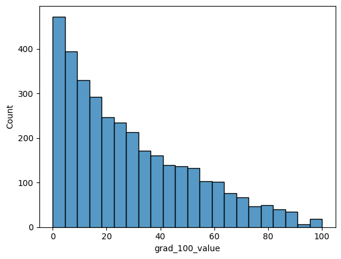

```python
import seaborn as sns
sns.histplot(df['grad_100_value'])
```

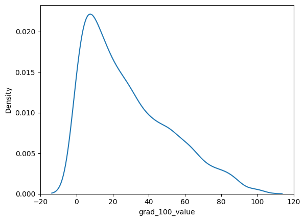

```python
sns.kdeplot(df['grad_100_value'])
```

```python
df['grad_100_value'].describe()
```

```
count    3467.000000
mean       28.364465
std        23.312730
min         0.000000
25%         9.000000
50%        22.500000
75%        43.650000
max       100.000000
Name: grad_100_value, dtype: float64
```

5

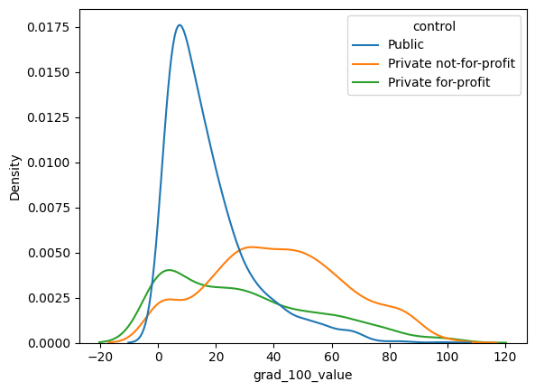

```python
sns.kdeplot(data=df,x='grad_100_value',hue='control')
```

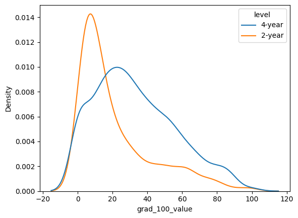

```python
sns.kdeplot(data=df,x='grad_100_value',hue='level')
```

```python
df.loc[:,['control','grad_100_value']].groupby('control').describe()
```

| control | grad_100_value count | grad_100_value mean | grad_100_value std | grad_100_value min | grad_100_value 25% | grad_100_value 50% | grad_100_value 75% | grad_100_value max |
| --- | --- | --- | --- | --- | --- | --- | --- | --- |
| Private for-profit | 779.0 | 29.108858 | 25.601687 | 0.0 | 6.95 | 24.7 | 46.75 | 100.0 |
| Private not-for-profit | 1189.0 | 41.660976 | 23.551231 | 0.0 | 25.00 | 41.0 | 58.30 | 100.0 |
| Public | 1499.0 | 17.430887 | 14.729443 | 0.0 | 6.90 | 13.2 | 23.25 | 97.8 |

```python
df.loc[:,['level','grad_100_value']].groupby('level').describe()
```

| level | grad_100_value count | grad_100_value mean | grad_100_value std | grad_100_value min | grad_100_value 25% | grad_100_value 50% | grad_100_value 75% | grad_100_value max |
| --- | --- | --- | --- | --- | --- | --- | --- | --- |
| 2-year | 1455.0 | 21.636151 | 21.645747 | 0.0 | 6.0 | 13.0 | 30.600 | 100.0 |
| 4-year | 2012.0 | 33.230119 | 23.270160 | 0.0 | 15.2 | 29.7 | 49.225 | 100.0 |

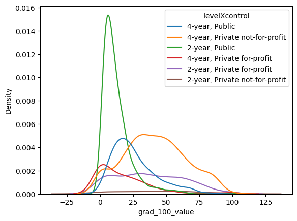

```python
df['levelXcontrol']=df['level']+', '+df['control']
sns.kdeplot(data=df,x='grad_100_value',hue='levelXcontrol')
```

```python
df.loc[:,['level','control','grad_100_value']].groupby(['level','control']).describe()
```

| level | control | grad_100_value count | grad_100_value mean | grad_100_value std | grad_100_value min | grad_100_value 25% | grad_100_value 50% | grad_100_value 75% | grad_100_value max |
| --- | --- | --- | --- | --- | --- | --- | --- | --- | --- |
| 2-year | Private for-profit | 461.0 | 37.197614 | 25.497380 | 0.0 | 15.800 | 33.9 | 57.800 | 100.0 |
|  | Private not-for-profit | 68.0 | 41.913235 | 28.348302 | 0.0 | 16.225 | 44.4 | 61.200 | 100.0 |
|  | Public | 926.0 | 12.400000 | 10.893600 | 0.0 | 5.100 | 9.4 | 16.175 | 97.8 |
| 4-year | Private for-profit | 318.0 | 17.382704 | 20.788525 | 0.0 | 0.000 | 12.5 | 26.325 | 100.0 |
|  | Private not-for-profit | 1121.0 | 41.645674 | 23.243453 | 0.0 | 25.000 | 41.0 | 57.800 | 100.0 |
|  | Public | 573.0 | 25.561082 | 16.403902 | 0.0 | 13.600 | 21.8 | 33.800 | 86.3 |

7

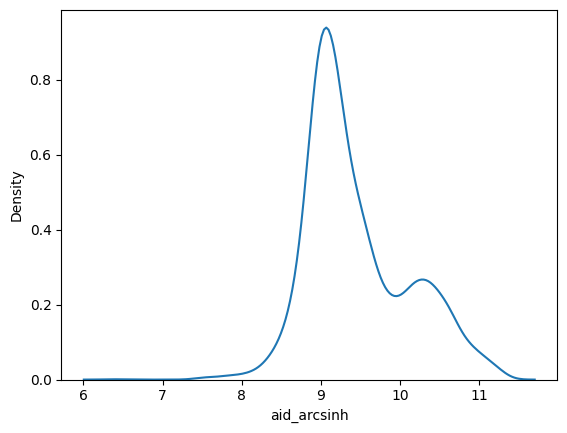

```python
df['aid_arcsinh'] = np.arcsinh(df['aid_value'])
sns.kdeplot(data=df,x='aid_arcsinh')
```

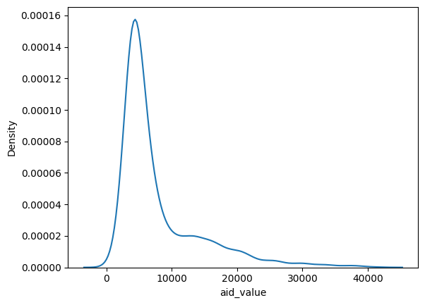

```python
sns.kdeplot(data=df,x='aid_value')
```

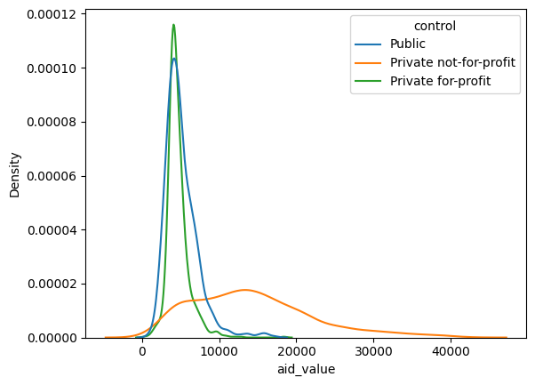

```python
sns.kdeplot(data=df,x='aid_value',hue='control')
```

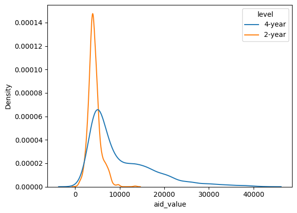

```python
sns.kdeplot(data=df,x='aid_value',hue='level')
```

```python
df.loc[:,['level','aid_value']].groupby('level').describe()
```

| level | aid_value count | aid_value mean | aid_value std | aid_value min | aid_value 25% | aid_value 50% | aid_value 75% | aid_value max |
| --- | --- | --- | --- | --- | --- | --- | --- | --- |
| 2-year | 1458.0 | 4310.878601 | 1384.045631 | 294.0 | 3485.5 | 4113.0 | 4890.0 | 13654.0 |
| 4-year | 2339.0 | 10235.379222 | 7227.369167 | 902.0 | 4830.5 | 7222.0 | 14046.0 | 41580.0 |

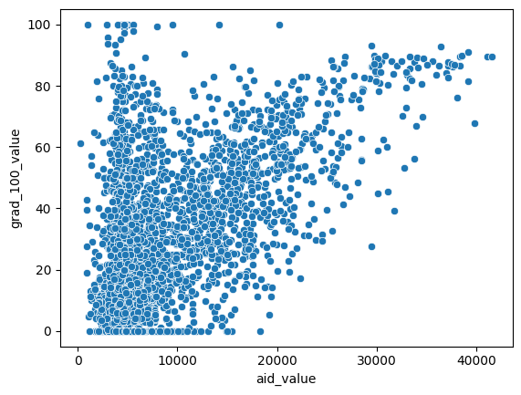

```python
sns.scatterplot(data=df,x='aid_value',y='grad_100_value')
```

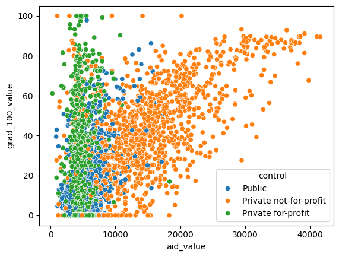

```python
sns.scatterplot(data=df,x='aid_value',y='grad_100_value',hue='control')
```

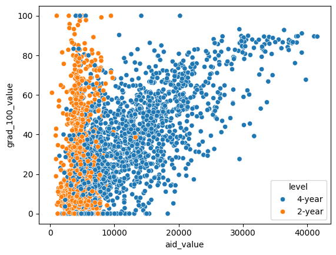

```python
sns.scatterplot(data=df,x='aid_value',y='grad_100_value',hue='level')
```

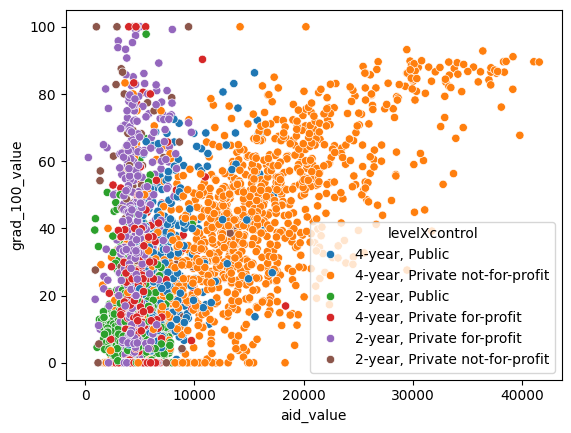

```python
sns.scatterplot(data=df,x='aid_value',y='grad_100_value',hue='levelXcontrol')
```

Question 4

4. For the variables you select, make a boxplot for each numeric variable and a bar graph for each categorical variable. Do you see any outliers?
5. Create a histogram or kernel density plot, and explain what you see. Do the results require any transformations to rescale them?
6. Create a scatter plot, and describe the relationship you see.
7. Create a table (cross tabulation, variance-covariance, or a .describe() five-number summary), and explain what you see.

I chose the Order and Referring data set, which has information on all physicians and non-physician practitioners.

No, it does not document how missing variables are handled. It doesn't describe possible values and missing calue code for categorical variables nor numeric values. The dictionary in general provides good explanation of the data, such as whether a provider could or couldn't order, refer, and more. However, it does not explain how it manages missing data, which would be important to know/understand.

PartB is interesting because it indicates whether a provider was able to refer to Medicare, informing what role a provider has in referring patients to Medicare. This stood out to me because generally, medical professionals don't like federal plans since they see it as a loss compared to what they could gain from other insurance companies/out of pocket patients. DME is also interesting because it it tells whether a provider can order durable medical equipment - i think this is important as it shows what abilities providers have in this aspect for their facilities. There is no missing or incorrect values in the dataset. Its already in the correct format too.

```python
import os
import pandas as pd
```

```python
file_path = '/Users/angievasquez/Downloads/OrderReferring_20240930.csv'
```

```python
df = pd.read_csv(file_path)
```

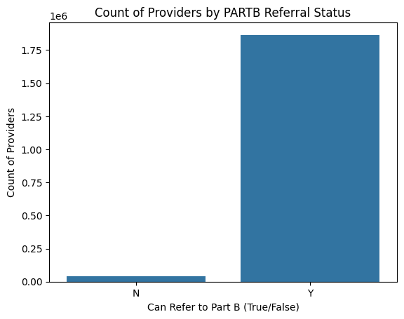

```python
sns.countplot(data=df, x='PARTB')
plt.title('Count of Providers by PARTB Referral Status')
plt.xlabel('Can Refer to Part B (True/False)')
plt.ylabel('Count of Providers')
plt.show()
```

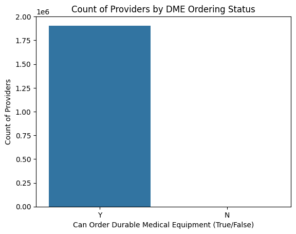

```python
sns.countplot(data=df, x='DME')
plt.title('Count of Providers by DME Ordering Status')
plt.xlabel('Can Order Durable Medical Equipment (True/False)')
plt.ylabel('Count of Providers')
plt.show()
```

No outliers

```python
import seaborn as sns
import matplotlib.pyplot as plt
```

```python
df['PARTB_numeric'] = df['PARTB'].map({True: 1, False: 0})
```

[figure not shown]

```python
plt.figure(figsize=(8, 5))
sns.histplot(df['PARTB_numeric'], bins=2, kde=False, color='blue')
plt.title('Histogram of PARTB Referral Status')
plt.xticks([0, 1], ['Cannot Refer (False)', 'Can Refer (True)'])
plt.xlabel('PARTB Referral Status')
plt.ylabel('Frequency')
plt.show()
```

```python
print(df['PARTB'].value_counts())
```

```
PARTB
Y    1865081
N      40677
Name: count, dtype: int64
```

```python
print(df['PARTB'].isnull().sum())
```

```
0
```

categorical v numerical

```python
sns.scatterplot(data=df, x='dme', y='PARTB')
plt.title('Scatter Plot of DME vs PARTB')
plt.xlabel('DME')
plt.ylabel('PARTB')
plt.show()
```

[output not shown]

[output cut: 24 more lines]

[output not shown]